# Viaje a través de Nuestro Chat de WhatsApp 👩🏻‍❤️‍👨🏾💬

## Introducción

En este recorrido, exploraremos nuestro mundo de conversaciones en WhatsApp. Desde el primer "Hola" hasta los emoticones que hacen que nuestro corazón sonría. ¡Vamos juntos a recordar esos momentos especiales!

## Nuestro Chat en Números 💬📊

### Nuestra Conexión Única

En este viaje numérico a través de nuestro chat, descubriremos cuántos mensajes hemos intercambiado. Cada palabra, una expresión única de nuestro vínculo, una conversación que solo nosotros entendemos.

|  | Miembro | Mensaje |
| --- | --- | --- |
| 1 | Raynier | 14664 |
| 2 | Negra ❤️ | 13949 |

### Emojis, los Pequeños Emisarios de Nuestro Amor 💖

#### Descifrando Nuestros Emoticones

Los emoticones son nuestras pequeñas expresiones digitales, nuestros cómplices silenciosos. Desde la risa contagiosa hasta los corazones que laten juntos, estos emoticones cuentan la historia de nuestro amor en pequeños iconos llenos de significado.

| Emoji | Cantidad |
| --- | --- |
| ❤️ | 301 |
| 🤣 | 242 |
| 😍 | 228 |
| 🤭 | 173 |
| 🫣 | 158 |
| 😪 | 144 |
| 😌 | 139 |
| 🥲 | 124 |
| 🤤 | 115 |
| 😏 | 111 |
| 😑 | 108 |
| 😬 | 106 |
| 😘 | 94 |
| 🥺 | 92 |
| 😮 | 85 |
| 💓 | 78 |
| 🫶🏼 | 71 |
| 🫶🏾 | 63 |
| 😳 | 58 |
| 🥰 | 57 |
| 😢 | 51 |
| 🙊 | 51 |
| 🙄 | 49 |
| 😔 | 42 |
| 🫠 | 39 |
| 😐 | 38 |
| 😕 | 22 |
| 🥹 | 21 |
| 😅 | 20 |
| 😂 | 17 |

#### El Colorido Pastel de Nuestros Sentimientos

Imagina un pastel adornado con los emojis que más usamos. Cada rebanada cuenta una historia, cada color refleja una emoción compartida. Este pastel es un festín visual de nuestra conexión emocional.

[interactive chart not shown]

### Instantáneas de Nuestro Mundo 📸

En esta sección, echaremos un vistazo a las instantáneas de nuestro mundo digital. Desde mensajes escritos con amor hasta momentos compartidos en forma de fotos, exploraremos la diversidad de nuestra comunicación y los recuerdos multimedia que hemos coleccionado.

| Tipo | Cantidad |
| --- | --- |
| Messages | 28613 |
| Multimedia | 6797 |
| Emojis | 3215 |
| Links | 206 |
| Polls | 3 |

| Estadísticas | Mensajes | Palabras por mensaje | Multimedia | Emojis | Links |
| --- | --- | --- | --- | --- | --- |
| Raynier | 12808 | 7.301843 | 1856 | 1662 | 73 |
| Negra ❤️ | 9036 | 5.669987 | 4913 | 1553 | 133 |

## Detalles Especiales 💖✨

### Nuestras Horas Mágicas ⌛💫

Las horas mágicas son esos momentos del día en los que nuestros mensajes florecen. Ya sea en la serenidad de la mañana o en la calidez de la noche, descubriremos cuándo nuestras palabras cobran vida con mayor intensidad.

[interactive chart not shown]

### Nuestro Calendario del Amor 📅❤️

Este calendario es más que fechas; es un registro de nuestro compromiso diario. Observaremos cómo nuestros mensajes se entrelazan en el tiempo, creando un patrón que refleja el flujo constante de nuestro amor a lo largo de los días.

[interactive chart not shown]

### El Poema de Nuestras Palabras 📜🖋️

Cada palabra que compartimos es una línea en el poema de nuestro amor. En esta sección, exploraremos las palabras más usadas, creando una nube de términos que resalta las esencias más dulces y comunes de nuestras conversaciones.

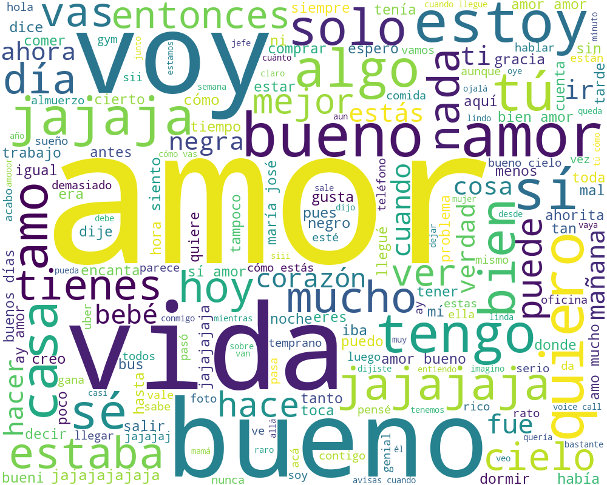

## Reflexiones de Nuestro Viaje 💭💕

En este viaje a través de nuestro chat, hemos revivido esos momentos que solo tú y yo entendemos. Cada emoji, cada palabra, cada enlace es una pequeña pieza de nuestro amor que ha quedado registrado. Gracias por ser mi compañera de viaje en este hermoso chat de WhatsApp.